# Johnson City Crime Analysis

Evan Larsen

May 10, 2019

# Project Explaination

This project will look at 8 types of crime to see if they are more or less likely to happen on either a certain day of the week or a certain month of the year. The types are:

- Larceny
- Burglary
- Robbery
- Traffic Offenses
- Drug Offenses
- Sex Crimes
- Disturbances
- Other

# Hypotheses

I expect that some of these crimes will be correlated with either month and day, while others will not be. My hypotheses are:

H1- Larceny will be more likely to happen on weekends during the summer

H2- Burglary will not be any more likely to happen based off day nor month

H3- Robbery will not be any more likely to happen based off day nor month

H4- Traffic Offenses will be more likely to happen on weekends, and during the summer months

H5- Drug Offenses will be more likely to happen during the weekends

H6- Sex Crimes will be more likely to happen during the weekends

H7- Disturbances will not be any more likely to happen based off day nor month

H8- Other will not be any more likely to happen based off day nor month

# Libraries Needed

```r
if (!require(readr)) install.packages("readr")
library(readr)
if (!require(dplyr)) install.packages("dplyr")
library(dplyr)
if (!require(DT)) install.packages("DT")
library(DT)
if (!require(ggrepel)) install.packages("ggrepel")
library(ggrepel)
if (!require(ggrepel)) install.packages("ggplot2")
library(ggplot2)
if (!require(leaflet)) install.packages("leaflet")
library(leaflet)
if (!require(plyr)) install.packages("plyr")
library(plyr)
if (!require(ggmap)) install.packages("ggmap")
library(ggmap)
if (!require(lubridate)) install.packages("lubridate")
library(lubridate)
if (!require(sjPlot)) install.packages("sjPlot")
library(sjPlot)
```

# Data Proccessing

This section formats the 3 dataframes so they are useable for the various functions used within this project.

```r
Crime2016 <- data.frame(read.csv("crime2016.csv"))
Crime2016$newdate <- strptime(as.character(Crime2016$DATE_REPOR), "%m/%d/%Y")
Crime2016$DayOfWeek <- weekdays(as.Date(Crime2016$newdate))
Crime2016$Month <- months(Crime2016$newdate)
Crime2017 <- data.frame(read.csv("crime2017.csv"))
Crime2017$newdate <- strptime(as.character(Crime2017$DATE_REPOR), "%m/%d/%Y")
Crime2017$DayOfWeek <- weekdays(as.Date(Crime2017$newdate))
Crime2017$Month <- months(Crime2017$newdate)
Crime2018 <- data.frame(read.csv("crime2018.csv"))
Crime2018$newdate <- strptime(as.character(Crime2018$DATE_REPOR), "%m/%d/%Y")
Crime2018$DayOfWeek <- weekdays(as.Date(Crime2018$newdate))
Crime2018$Month <- months(Crime2018$newdate)
proper_case <- function(x) {
  return (gsub("\\b([A-Z])([A-Z]+)", "\\U\\1\\L\\2" , x, perl=TRUE))
}
Crime2016 <- Crime2016 %>% mutate(Address = proper_case(ADDRESS),
                    Crime = proper_case(OCCURRED_I))
Crime2017 <- Crime2017 %>% mutate(Address = proper_case(ADDRESS),
                    Crime = proper_case(OCCURRED_I))
Crime2018 <- Crime2018 %>% mutate(Address = proper_case(ADDRESS),
                    Crime = proper_case(OCCURRED_I))
Crime2016$City <-( " Johnson City, New York, USA")
Crime2017$City <- ( " Johnson City, New York, USA")
Crime2018$City <- ( " Johnson City, New York, USA")

Crime2016$NewAddress <- paste(Crime2016$Address, Crime2016$City, sep = ", ")
Crime2017$NewAddress <- paste(Crime2017$Address, Crime2017$City, sep = ", ")
Crime2018$NewAddress <- paste(Crime2018$Address, Crime2018$City, sep = ", ")
AllCrime <- rbind(Crime2016, Crime2017, Crime2018)
```

# Geocoding the data

This section runs the data through a Google API which geocodes each incident to get the lattitde and longitude.

```r
register_google(key = "AIzaSyA9Bpus_XLFtGfUr95eBf2Yc1XM5XiSdes", write = TRUE)
#####################################################
## load these one at a time otherwise R will crash ##
#####################################################
for(i in 1:nrow(Crime2016)){
  result <- geocode(Crime2016$NewAddress[i], output = "latlona", source = "google")
  Crime2016$lon[i] <- as.numeric(result[1])
  Crime2016$lat[i] <- as.numeric(result[2])
}
for(i in 1:nrow(Crime2017)){
  result <- geocode(Crime2017$NewAddress[i], output = "latlona", source = "google")
  Crime2017$lon[i] <- as.numeric(result[1])
  Crime2017$lat[i] <- as.numeric(result[2])
}
for(i in 1:nrow(Crime2018)){
  result <- geocode(Crime2018$NewAddress[i], output = "latlona", source = "google")
  Crime2018$lon[i] <- as.numeric(result[1])
  Crime2018$lat[i] <- as.numeric(result[2])
}



AllCrime <- rbind(Crime2016, Crime2017, Crime2018)
MonthFormat <-  c("January","February","March","April","May","June","July","August","September","October","November","December")
```

# Crime Map

This section uses the package “Leaflet” to map out where the crimes are happening. Due to a geocoding error some of the incidents took place not near the Village of Johnson City, so to view this please zoom to the area with the highest number on the cluster until you reach Johnson City.

```r
AllCrime$popup <- paste(
                    "<b>Type of crime: </b>", AllCrime$Type,
                    "<br>", "<b>Crime: </b>", AllCrime$Crime,
                    "<br>", "<b>Day of week: </b>", AllCrime$DayOfWeek,
                    "<br>", "<b>Date: </b>", AllCrime$DATE_REPOR,
                    "<br>", "<b>PD Address: </b>", AllCrime$NewAddress)
leaflet(AllCrime, width = "100%") %>% addTiles() %>%
  addTiles(group = "OSM (default)") %>%
  addProviderTiles(provider = "Esri.WorldStreetMap",group = "World StreetMap") %>%
  addProviderTiles(provider = "Esri.WorldImagery",group = "World Imagery") %>%
  addMarkers(lng = ~lon, lat = ~lat, popup = AllCrime$popup, clusterOptions = markerClusterOptions()) %>%
  addLayersControl(
    baseGroups = c("OSM (default)","World StreetMap", "World Imagery"),
    options = layersControlOptions(collapsed = FALSE)
  )
```

```
Data contains 19 rows with either missing or invalid lat/lon values and will be ignored
```

[interactive chart not shown]

# Bar Charts

To show which types of crime was committed the most per year I created bar charts for each year.

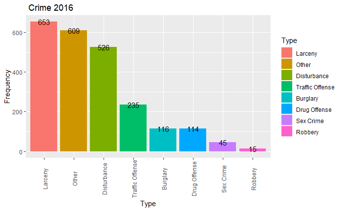

```r
MonthFormat <-  c("January","February","March","April","May","June","July","August","September","October","November","December")
CrimeTypeOrder <- c("Larceny", "Other", "Disturbance", "Traffic Offense", "Burglary", "Drug Offense", "Sex Crime", "Robbery")
#Aggregating Data by type
##2016
Crime2016_Type <- sort(table(Crime2016$Type), decreasing = TRUE)
Crime2016_Type <- data.frame(Crime2016_Type)
colnames(Crime2016_Type) <- c("Type", "Frequency")
Crime2016_Type$Percentage <- Crime2016_Type$Frequency/sum(Crime2016_Type$Frequency)
##2017
Crime2017_Type <- sort(table(Crime2017$Type), decreasing = TRUE)
Crime2017_Type <- data.frame(Crime2017_Type)
colnames(Crime2017_Type) <- c("Type", "Frequency")
Crime2017_Type$Percentage <- Crime2017_Type$Frequency/sum(Crime2017_Type$Frequency)
##2018
Crime2018_Type <- sort(table(Crime2018$Type), decreasing = TRUE)
Crime2018_Type <- data.frame(Crime2018_Type)
colnames(Crime2018_Type) <- c("Type", "Frequency")
Crime2018_Type$Percentage <- Crime2018_Type$Frequency/sum(Crime2018_Type$Frequency)
##AllCrime
AllCrime_Type <- sort(table(AllCrime$Type), decreasing = TRUE)
AllCrime_Type <- data.frame(AllCrime_Type)
colnames(AllCrime_Type) <- c("Type", "Frequency")
AllCrime_Type$Percentage <- AllCrime_Type$Frequency/sum(AllCrime_Type$Frequency)
#Bar Graphs
##2016
Crime2016BarGraph<-ggplot(Crime2016_Type, aes(x=Type, y=Frequency, fill=Type)) + geom_bar(stat="identity") +
  theme(axis.text.x=element_blank()) + ggtitle(" Crime 2016") + theme(axis.text.x =  element_text(angle = 90, vjust = 0.6)) +   geom_text(aes(label=Frequency))
Crime2016BarGraph
```

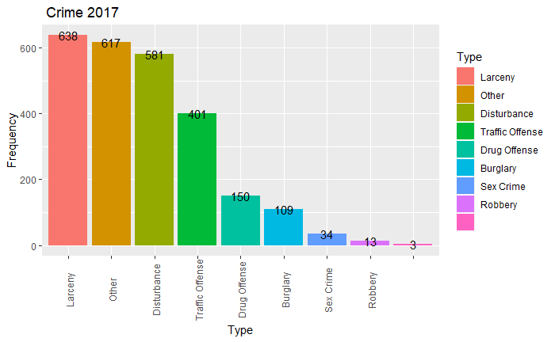

```r
##2017
Crime2017BarGraph<-ggplot(Crime2017_Type, aes(x=Type, y=Frequency, fill=Type)) + geom_bar(stat="identity") +
  theme(axis.text.x=element_blank())  + ggtitle(" Crime 2017") + theme(axis.text.x =  element_text(angle = 90, vjust = 0.6)) +   geom_text(aes(label=Frequency))
Crime2017BarGraph
```

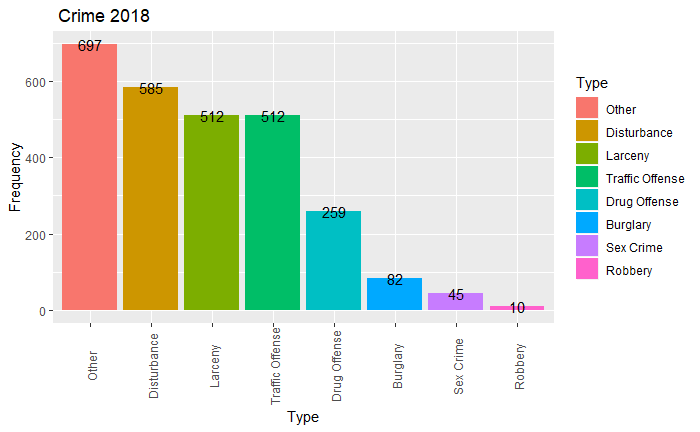

```r
#2018
Crime2018BarGraph<-ggplot(Crime2018_Type, aes(x=Type, y=Frequency, fill=Type)) + geom_bar(stat="identity") +
  theme(axis.text.x=element_blank()) + ggtitle(" Crime 2018")  + theme(axis.text.x =  element_text(angle = 90, vjust = 0.6))+   geom_text(aes(label=Frequency))
Crime2018BarGraph
```

# Temporal Heat Maps

For each type of crime I created time-based heat maps, one for each year, showing the correlation between the type of crime and both the day of the week and the month of the year. These time-based allow the viewer to detect patterns in when crimes have been committed the most historically.

## Larceny

These time-based heat maps from 2016 and 2018 for larceny show a higher amount of larcenies occurring between July and September. These years also show a higher number of larcenies occurring between Wednesdays and Fridays. The days of the week within 2017 followed a similar pattern as the previous years.

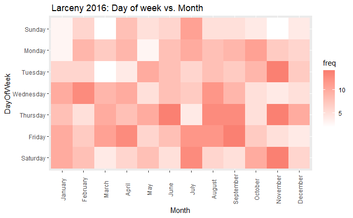

```r
#Larceny
Crime2016MonthLarceny <- count(Crime2016[Crime2016$Type == 'Larceny',], vars = c( "Month" , "Type" , "DayOfWeek"))
Crime2016MonthLarceny$DayOfWeek <- factor(Crime2016MonthLarceny$DayOfWeek, order = TRUE, levels = c( "Saturday","Friday","Thursday", "Wednesday", "Tuesday", "Monday", "Sunday"))
Crime2016MonthLarceny$Month <- factor(Crime2016MonthLarceny$Month, order = TRUE, levels = MonthFormat)
Crime2017MonthLarceny <- count(Crime2017[Crime2017$Type == 'Larceny',], vars = c( "Month" , "Type" , "DayOfWeek"))
Crime2017MonthLarceny$DayOfWeek <- factor(Crime2017MonthLarceny$DayOfWeek, order = TRUE, levels = c( "Saturday","Friday","Thursday", "Wednesday", "Tuesday", "Monday", "Sunday"))
Crime2017MonthLarceny$Month <- factor(Crime2017MonthLarceny$Month, order = TRUE, levels = MonthFormat)
Crime2018MonthLarceny <- count(Crime2018[Crime2018$Type == 'Larceny',], vars = c( "Month" , "Type" , "DayOfWeek"))
Crime2018MonthLarceny$DayOfWeek <- factor(Crime2018MonthLarceny$DayOfWeek, order = TRUE, levels = c( "Saturday","Friday","Thursday", "Wednesday", "Tuesday", "Monday", "Sunday"))
Crime2018MonthLarceny$Month <- factor(Crime2018MonthLarceny$Month, order = TRUE, levels = MonthFormat)
##Larceny
ggplot(Crime2016MonthLarceny, aes(x = Month, y = DayOfWeek, fill = freq)) + geom_tile() + scale_fill_gradient(low="white", high="salmon") + ggtitle(" Larceny 2016: Day of week vs. Month")  + theme(axis.text.x = element_text(angle = 90, vjust = 0.6))
```

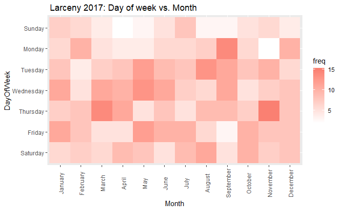

```r
ggplot(Crime2017MonthLarceny, aes(x = Month, y = DayOfWeek, fill = freq)) + geom_tile() + scale_fill_gradient(low="white", high="salmon") + ggtitle(" Larceny 2017: Day of week vs. Month")  + theme(axis.text.x = element_text(angle = 90, vjust = 0.6))
```

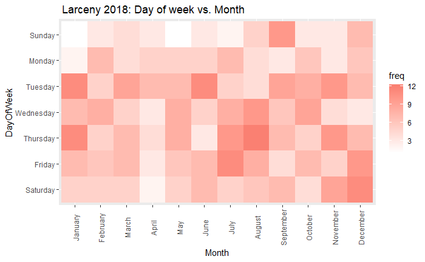

```r
ggplot(Crime2018MonthLarceny, aes(x = Month, y = DayOfWeek, fill = freq)) + geom_tile() + scale_fill_gradient(low="white", high="salmon") + ggtitle(" Larceny 2018: Day of week vs. Month")  + theme(axis.text.x = element_text(angle = 90, vjust = 0.6))
```

## Other

Other crimes is the second largest group for 2016 and 2017, and the largest group for 2018. Other crimes is comprise of various crimes and violations that do not fit into the other 7 groups, and are not significant enough themselves to have their own type. Due to what other crimes is comprised of there are no patterns.

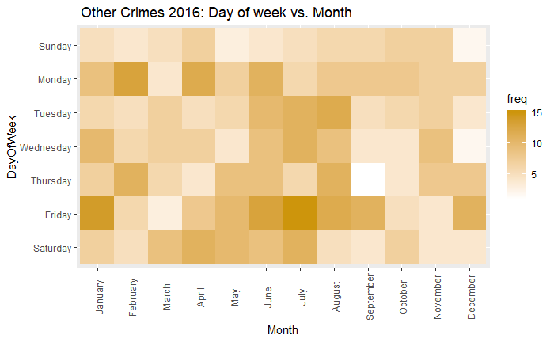

```r
#Other
Crime2016MonthOther <- count(Crime2016[Crime2016$Type == 'Other',], vars = c( "Month" , "Type" , "DayOfWeek"))
Crime2016MonthOther$DayOfWeek <- factor(Crime2016MonthOther$DayOfWeek, order = TRUE, levels = c( "Saturday","Friday","Thursday", "Wednesday", "Tuesday", "Monday", "Sunday"))
Crime2016MonthOther$Month <- factor(Crime2016MonthOther$Month, order = TRUE, levels = MonthFormat)
Crime2017MonthOther <- count(Crime2017[Crime2017$Type == 'Other',], vars = c( "Month" , "Type" , "DayOfWeek"))
Crime2017MonthOther$DayOfWeek <- factor(Crime2017MonthOther$DayOfWeek, order = TRUE, levels = c( "Saturday","Friday","Thursday", "Wednesday", "Tuesday", "Monday", "Sunday"))
Crime2017MonthOther$Month <- factor(Crime2017MonthOther$Month, order = TRUE, levels = MonthFormat)
Crime2018MonthOther <- count(Crime2018[Crime2018$Type == 'Other',], vars = c( "Month" , "Type" , "DayOfWeek"))
Crime2018MonthOther$DayOfWeek <- factor(Crime2018MonthOther$DayOfWeek, order = TRUE, levels = c( "Saturday","Friday","Thursday", "Wednesday", "Tuesday", "Monday", "Sunday"))
Crime2018MonthOther$Month <- factor(Crime2018MonthOther$Month, order = TRUE, levels = MonthFormat)
##other
ggplot(Crime2016MonthOther, aes(x = Month, y = DayOfWeek, fill = freq)) + geom_tile() + scale_fill_gradient(low="white", high="darkgoldenrod3") + ggtitle(" Other Crimes 2016: Day of week vs. Month") + theme(axis.text.x =  element_text(angle = 90, vjust = 0.6))
```

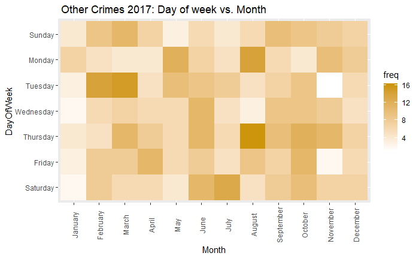

```r
ggplot(Crime2017MonthOther, aes(x = Month, y = DayOfWeek, fill = freq)) + geom_tile() + scale_fill_gradient(low="white", high="darkgoldenrod3") + ggtitle(" Other Crimes 2017: Day of week vs. Month") + theme(axis.text.x =  element_text(angle = 90, vjust = 0.6))
```

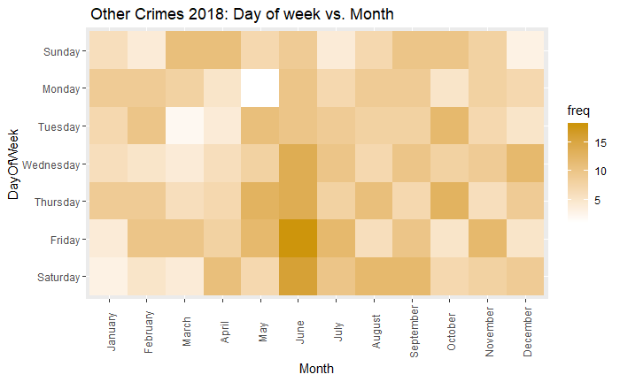

```r
ggplot(Crime2018MonthOther, aes(x = Month, y = DayOfWeek, fill = freq)) + geom_tile() + scale_fill_gradient(low="white", high="darkgoldenrod3") + ggtitle(" Other Crimes 2018: Day of week vs. Month") + theme(axis.text.x =  element_text(angle = 90, vjust = 0.6))
```

## Disturbances

There are no noticeable patterns for disturbances.

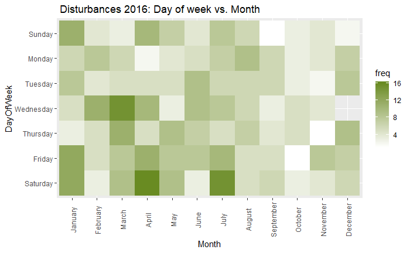

```r
#Disturbances
Crime2016MonthDisturbances <- count(Crime2016[Crime2016$Type == 'Disturbance',], vars = c( "Month" , "Type" , "DayOfWeek"))
Crime2016MonthDisturbances$DayOfWeek <- factor(Crime2016MonthDisturbances$DayOfWeek, order = TRUE, levels = c( "Saturday","Friday","Thursday", "Wednesday", "Tuesday", "Monday", "Sunday"))
Crime2016MonthDisturbances$Month <- factor(Crime2016MonthDisturbances$Month, order = TRUE, levels = MonthFormat)
Crime2017MonthDisturbances <- count(Crime2017[Crime2017$Type == 'Disturbance',], vars = c( "Month" , "Type" , "DayOfWeek"))
Crime2017MonthDisturbances$DayOfWeek <- factor(Crime2017MonthDisturbances$DayOfWeek, order = TRUE, levels = c( "Saturday","Friday","Thursday", "Wednesday", "Tuesday", "Monday", "Sunday"))
Crime2017MonthDisturbances$Month <- factor(Crime2017MonthDisturbances$Month, order = TRUE, levels = MonthFormat)
Crime2018MonthDisturbances <- count(Crime2018[Crime2018$Type == 'Disturbance',], vars = c( "Month" , "Type" , "DayOfWeek"))
Crime2018MonthDisturbances$DayOfWeek <- factor(Crime2018MonthDisturbances$DayOfWeek, order = TRUE, levels = c( "Saturday","Friday","Thursday", "Wednesday", "Tuesday", "Monday", "Sunday"))
Crime2018MonthDisturbances$Month <- factor(Crime2018MonthDisturbances$Month, order = TRUE, levels = MonthFormat)
#disturbances
ggplot(Crime2016MonthDisturbances, aes(x = Month, y = DayOfWeek, fill = freq)) + geom_tile() + scale_fill_gradient(low="white", high="olivedrab4") + ggtitle(" Disturbances 2016: Day of week vs. Month") + theme(axis.text.x =  element_text(angle = 90, vjust = 0.6))
```

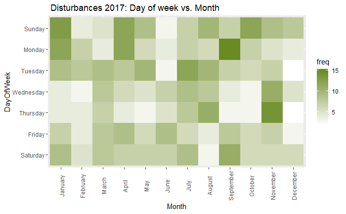

```r
ggplot(Crime2017MonthDisturbances, aes(x = Month, y = DayOfWeek, fill = freq)) + geom_tile() + scale_fill_gradient(low="white", high="olivedrab4") + ggtitle(" Disturbances 2017: Day of week vs. Month") + theme(axis.text.x =  element_text(angle = 90, vjust = 0.6))
```

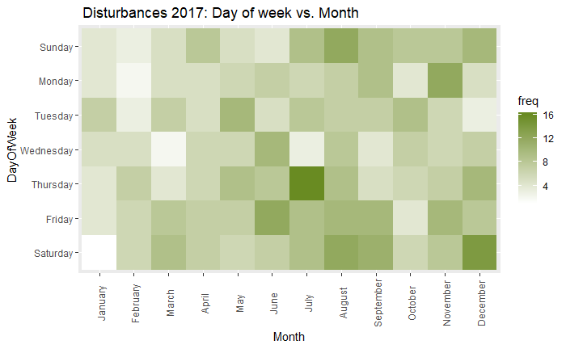

```r
ggplot(Crime2018MonthDisturbances, aes(x = Month, y = DayOfWeek, fill = freq)) + geom_tile() + scale_fill_gradient(low="white", high="olivedrab4") + ggtitle(" Disturbances 2017: Day of week vs. Month") + theme(axis.text.x =  element_text(angle = 90, vjust = 0.6))
```

## Traffic Offense

Based off these time-based heat maps traffic offenses appear to be most prominent on Fridays and Saturdays. Traffic offenses are least likely to happen in December of each year.

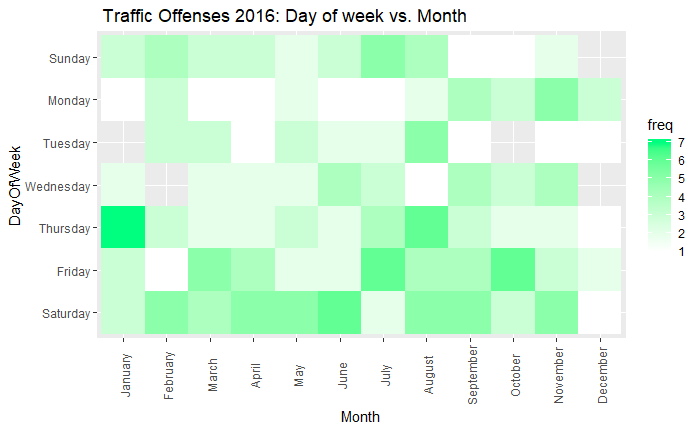

```r
#TrafficOffense
x <- count(Crime2016[Crime2016$Type == 'Traffic Offense',], vars = c( "Month" , "Type" , "DayOfWeek"))
x$DayOfWeek <- factor(x$DayOfWeek, order = TRUE, levels = c( "Saturday","Friday","Thursday", "Wednesday", "Tuesday", "Monday", "Sunday"))
x$Month <- factor(x$Month, order = TRUE, levels = MonthFormat)
Crime2016MonthTraffic <- x
x <- count(Crime2017[Crime2017$Type == 'Traffic Offense',], vars = c( "Month" , "Type" , "DayOfWeek"))
x$DayOfWeek <- factor(x$DayOfWeek, order = TRUE, levels = c( "Saturday","Friday","Thursday", "Wednesday", "Tuesday", "Monday", "Sunday"))
x$Month <- factor(x$Month, order = TRUE, levels = MonthFormat)
Crime2017MonthTraffic <- x
x <- count(Crime2018[Crime2018$Type == 'Traffic Offense',], vars = c( "Month" , "Type" , "DayOfWeek"))
x$DayOfWeek <- factor(x$DayOfWeek, order = TRUE, levels = c( "Saturday","Friday","Thursday", "Wednesday", "Tuesday", "Monday", "Sunday"))
x$Month <- factor(x$Month, order = TRUE, levels = MonthFormat)
Crime2018MonthTraffic <- x
##Traffic
ggplot(Crime2016MonthTraffic, aes(x = Month, y = DayOfWeek, fill = freq)) + geom_tile() + scale_fill_gradient(low="white", high="springgreen") + ggtitle(" Traffic Offenses 2016: Day of week vs. Month") + theme(axis.text.x =  element_text(angle = 90, vjust = 0.6))
```

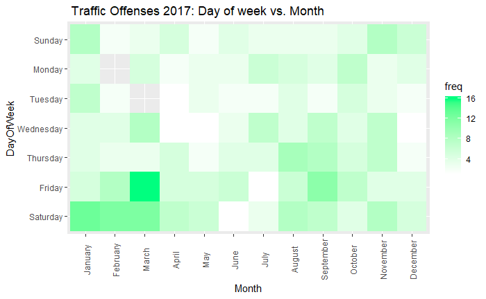

```r
ggplot(Crime2017MonthTraffic, aes(x = Month, y = DayOfWeek, fill = freq)) + geom_tile() + scale_fill_gradient(low="white", high="springgreen") + ggtitle(" Traffic Offenses 2017: Day of week vs. Month") + theme(axis.text.x =  element_text(angle = 90, vjust = 0.6))
```

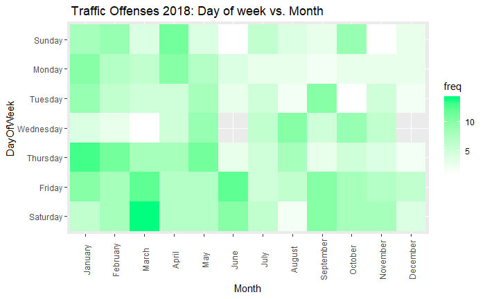

```r
ggplot(Crime2018MonthTraffic, aes(x = Month, y = DayOfWeek, fill = freq)) + geom_tile() + scale_fill_gradient(low="white", high="springgreen") + ggtitle(" Traffic Offenses 2018: Day of week vs. Month") + theme(axis.text.x =  element_text(angle = 90, vjust = 0.6))
```

## Burglary

There are no noticeable patterns for disturbances.

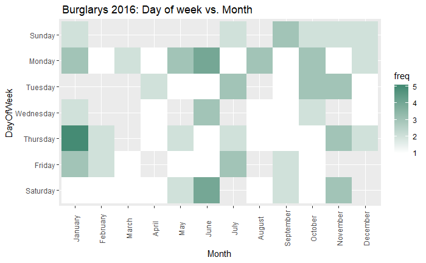

```r
###burglary
Crime2016MonthBurg <- count(Crime2016[Crime2016$Type == 'Burglary',], vars = c( "Month" , "Type" , "DayOfWeek"))
Crime2016MonthBurg$DayOfWeek <- factor(Crime2016MonthBurg$DayOfWeek, order = TRUE, levels = c( "Saturday","Friday","Thursday", "Wednesday", "Tuesday", "Monday", "Sunday"))
Crime2016MonthBurg$Month <- factor(Crime2016MonthBurg$Month, order = TRUE, levels = MonthFormat)
Crime2017MonthBurg <- count(Crime2017[Crime2017$Type == 'Burglary',], vars = c( "Month" , "Type" , "DayOfWeek"))
Crime2017MonthBurg$DayOfWeek <- factor(Crime2017MonthBurg$DayOfWeek, order = TRUE, levels = c( "Saturday","Friday","Thursday", "Wednesday", "Tuesday", "Monday", "Sunday"))
Crime2017MonthBurg$Month <- factor(Crime2017MonthBurg$Month, order = TRUE, levels = MonthFormat)
Crime2018MonthBurg <- count(Crime2018[Crime2018$Type == 'Burglary',], vars = c( "Month" , "Type" , "DayOfWeek"))
Crime2018MonthBurg$DayOfWeek <- factor(Crime2018MonthBurg$DayOfWeek, order = TRUE, levels = c( "Saturday","Friday","Thursday", "Wednesday", "Tuesday", "Monday", "Sunday"))
Crime2018MonthBurg$Month <- factor(Crime2018MonthBurg$Month, order = TRUE, levels = MonthFormat)
##Burgleries
ggplot(Crime2016MonthBurg, aes(x = Month, y = DayOfWeek, fill = freq))  + geom_tile() + scale_fill_gradient(low="white", high="aquamarine4") +  ggtitle(" Burglarys 2016: Day of week vs. Month") + theme(axis.text.x =  element_text(angle = 90, vjust = 0.6))
```

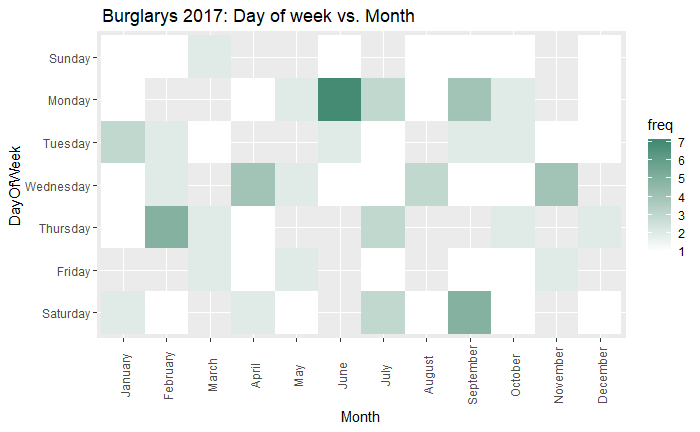

```r
ggplot(Crime2017MonthBurg, aes(x = Month, y = DayOfWeek, fill = freq))  + geom_tile() + scale_fill_gradient(low="white", high="aquamarine4") +  ggtitle(" Burglarys 2017: Day of week vs. Month") + theme(axis.text.x =  element_text(angle = 90, vjust = 0.6))
```

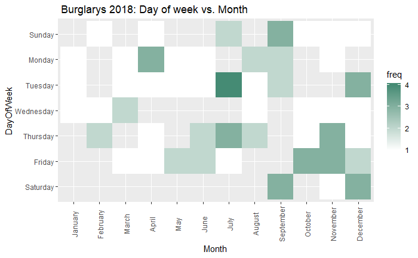

```r
ggplot(Crime2018MonthBurg, aes(x = Month, y = DayOfWeek, fill = freq))  + geom_tile() + scale_fill_gradient(low="white", high="aquamarine4") +  ggtitle(" Burglarys 2018: Day of week vs. Month") + theme(axis.text.x =  element_text(angle = 90, vjust = 0.6))
```

## Drug Offense

Based off the time-based heatmaps for 2016 and 2017 there are more likely to be drug offenses on Thursdays and Fridays. There are no discernable patterns between drug offenses and months. There are also no discernable patterns within 2018.

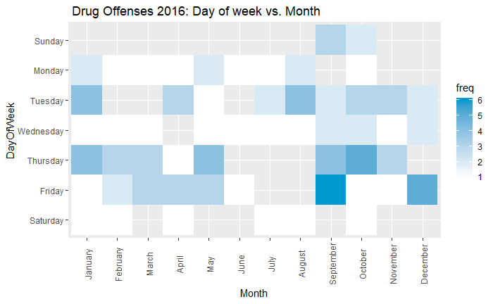

```r
#Data
x <- count(Crime2016[Crime2016$Type == 'Drug Offense',], vars = c( "Month" , "Type" , "DayOfWeek"))
x$DayOfWeek <- factor(x$DayOfWeek, order = TRUE, levels = c( "Saturday","Friday","Thursday", "Wednesday", "Tuesday", "Monday", "Sunday"))
x$Month <- factor(x$Month, order = TRUE, levels = MonthFormat)
Crime2016MonthDrugs <- x
x <- count(Crime2017[Crime2017$Type == 'Drug Offense',], vars = c( "Month" , "Type" , "DayOfWeek"))
x$DayOfWeek <- factor(x$DayOfWeek, order = TRUE, levels = c( "Saturday","Friday","Thursday", "Wednesday", "Tuesday", "Monday", "Sunday"))
x$Month <- factor(x$Month, order = TRUE, levels = MonthFormat)
Crime2017MonthDrugs <- x
x <- count(Crime2018[Crime2018$Type == 'Drug Offense',], vars = c( "Month" , "Type" , "DayOfWeek"))
x$DayOfWeek <- factor(x$DayOfWeek, order = TRUE, levels = c( "Saturday","Friday","Thursday", "Wednesday", "Tuesday", "Monday", "Sunday"))
x$Month <- factor(x$Month, order = TRUE, levels = MonthFormat)
Crime2018MonthDrugs <- x
##Plotting
ggplot(Crime2016MonthDrugs, aes(x = Month, y = DayOfWeek, fill = freq)) + geom_tile() + scale_fill_gradient(low="white", high="deepskyblue3") + ggtitle(" Drug Offenses 2016: Day of week vs. Month") + theme(axis.text.x =  element_text(angle = 90, vjust = 0.6))
```

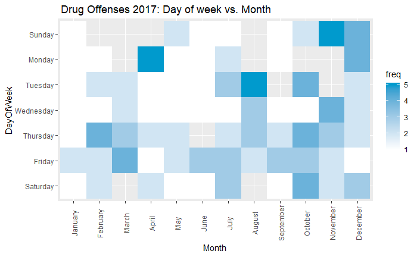

```r
ggplot(Crime2017MonthDrugs, aes(x = Month, y = DayOfWeek, fill = freq)) + geom_tile() + scale_fill_gradient(low="white", high="deepskyblue3") + ggtitle(" Drug Offenses 2017: Day of week vs. Month") + theme(axis.text.x =  element_text(angle = 90, vjust = 0.6))
```

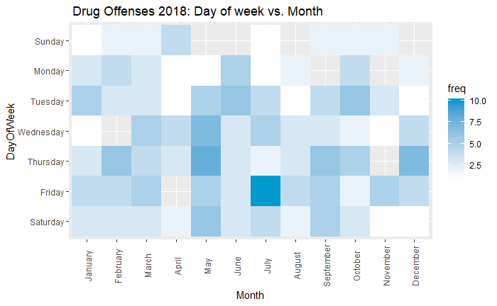

```r
ggplot(Crime2018MonthDrugs, aes(x = Month, y = DayOfWeek, fill = freq)) + geom_tile() + scale_fill_gradient(low="white", high="deepskyblue3") + ggtitle(" Drug Offenses 2018: Day of week vs. Month") + theme(axis.text.x =  element_text(angle = 90, vjust = 0.6))
```

## Sex Crime

There are not enough incidents for any discernable patterns for to appear.

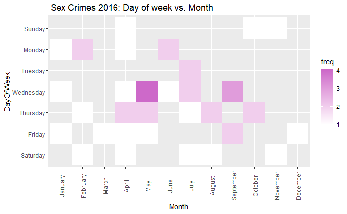

```r
#Sex Crimes
x <- count(Crime2016[Crime2016$Type == 'Sex Crime',], vars = c( "Month" , "Type" , "DayOfWeek"))
x$DayOfWeek <- factor(x$DayOfWeek, order = TRUE, levels = c( "Saturday","Friday","Thursday", "Wednesday", "Tuesday", "Monday", "Sunday"))
x$Month <- factor(x$Month, order = TRUE, levels = MonthFormat)
Crime2016MonthSex <- x
x <- count(Crime2017[Crime2017$Type == 'Sex Crime',], vars = c( "Month" , "Type" , "DayOfWeek"))
x$DayOfWeek <- factor(x$DayOfWeek, order = TRUE, levels = c( "Saturday","Friday","Thursday", "Wednesday", "Tuesday", "Monday", "Sunday"))
x$Month <- factor(x$Month, order = TRUE, levels = MonthFormat)
Crime2017MonthSex <- x
x <- count(Crime2018[Crime2018$Type == 'Sex Crime',], vars = c( "Month" , "Type" , "DayOfWeek"))
x$DayOfWeek <- factor(x$DayOfWeek, order = TRUE, levels = c( "Saturday","Friday","Thursday", "Wednesday", "Tuesday", "Monday", "Sunday"))
x$Month <- factor(x$Month, order = TRUE, levels = MonthFormat)
Crime2018MonthSex <- x
##Sexcrimes
ggplot(Crime2016MonthSex, aes(x = Month, y = DayOfWeek, fill = freq)) + geom_tile() + scale_fill_gradient(low="white", high="orchid3") + ggtitle(" Sex Crimes 2016: Day of week vs. Month") + theme(axis.text.x =  element_text(angle = 90, vjust = 0.6))
```

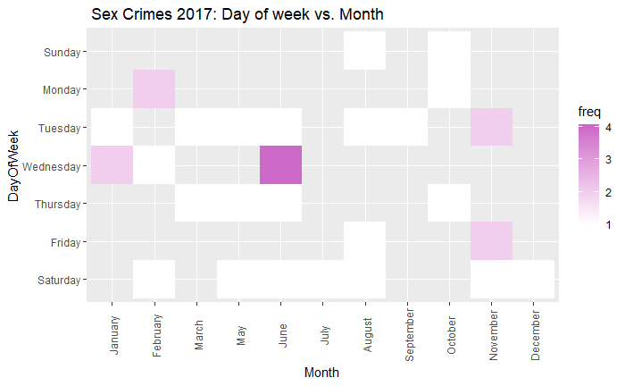

```r
ggplot(Crime2017MonthSex, aes(x = Month, y = DayOfWeek, fill = freq)) + geom_tile() + scale_fill_gradient(low="white", high="orchid3") + ggtitle(" Sex Crimes 2017: Day of week vs. Month") + theme(axis.text.x =  element_text(angle = 90, vjust = 0.6))
```

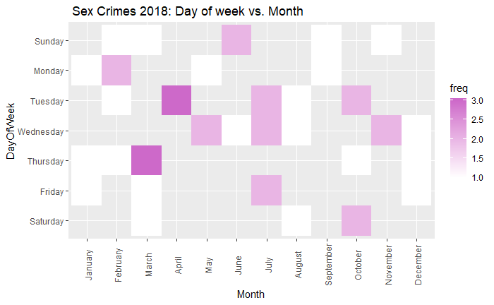

```r
ggplot(Crime2018MonthSex, aes(x = Month, y = DayOfWeek, fill = freq)) + geom_tile() + scale_fill_gradient(low="white", high="orchid3") + ggtitle(" Sex Crimes 2018: Day of week vs. Month") + theme(axis.text.x =  element_text(angle = 90, vjust = 0.6))
```

## Robbery

There are not enough incidents for any discernable patterns for to appear.

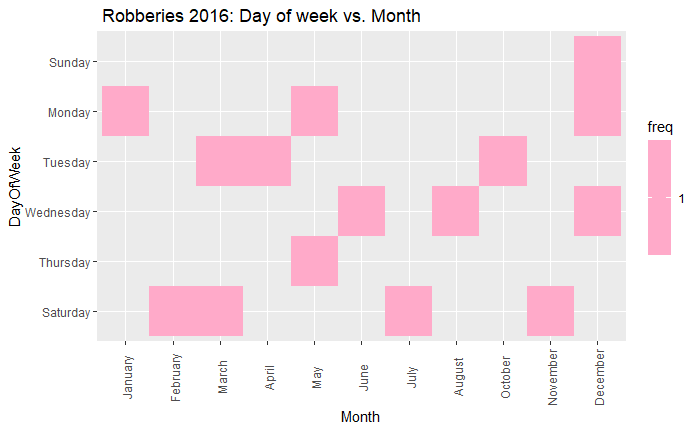

```r
#Robbery
x <- count(Crime2016[Crime2016$Type == 'Robbery',], vars = c( "Month" , "Type" , "DayOfWeek"))
x$DayOfWeek <- factor(x$DayOfWeek, order = TRUE, levels = c( "Saturday","Friday","Thursday", "Wednesday", "Tuesday", "Monday", "Sunday"))
x$Month <- factor(x$Month, order = TRUE, levels = MonthFormat)
Crime2016MonthRobbery <- x
x <- count(Crime2017[Crime2017$Type == 'Robbery',], vars = c( "Month" , "Type" , "DayOfWeek"))
x$DayOfWeek <- factor(x$DayOfWeek, order = TRUE, levels = c( "Saturday","Friday","Thursday", "Wednesday", "Tuesday", "Monday", "Sunday"))
x$Month <- factor(x$Month, order = TRUE, levels = MonthFormat)
Crime2017MonthRobbery <- x
x <- count(Crime2018[Crime2018$Type == 'Robbery',], vars = c( "Month" , "Type" , "DayOfWeek"))
x$DayOfWeek <- factor(x$DayOfWeek, order = TRUE, levels = c( "Saturday","Friday","Thursday", "Wednesday", "Tuesday", "Monday", "Sunday"))
x$Month <- factor(x$Month, order = TRUE, levels = MonthFormat)
Crime2018MonthRobbery <- x
#robbery
ggplot(Crime2016MonthRobbery, aes(x = Month, y = DayOfWeek, fill = freq)) + geom_tile() + scale_fill_gradient(low="white", high="violetred1") + ggtitle(" Robberies 2016: Day of week vs. Month") + theme(axis.text.x =  element_text(angle = 90, vjust = 0.6))
```

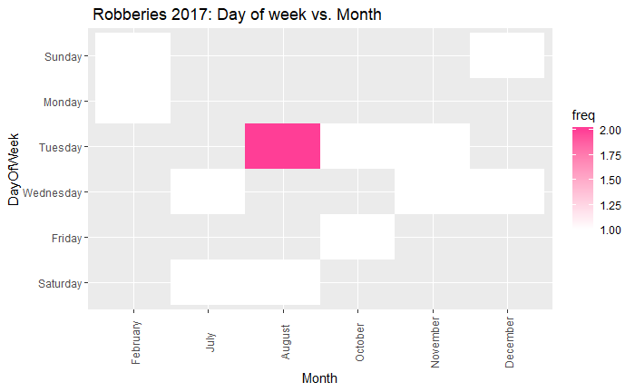

```r
ggplot(Crime2017MonthRobbery, aes(x = Month, y = DayOfWeek, fill = freq)) + geom_tile() + scale_fill_gradient(low="white", high="violetred1") + ggtitle(" Robberies 2017: Day of week vs. Month") + theme(axis.text.x =  element_text(angle = 90, vjust = 0.6))
```

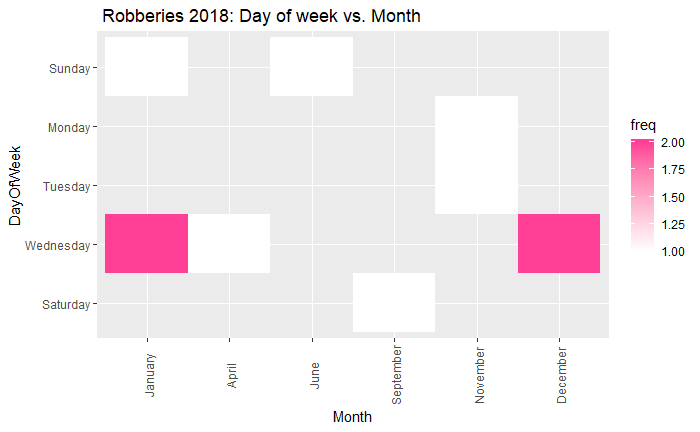

```r
ggplot(Crime2018MonthRobbery, aes(x = Month, y = DayOfWeek, fill = freq)) + geom_tile() + scale_fill_gradient(low="white", high="violetred1") + ggtitle(" Robberies 2018: Day of week vs. Month") + theme(axis.text.x =  element_text(angle = 90, vjust = 0.6))
```

# Outcome

H1- Larceny will be more likely to happen on weekends during the summer Reject

H2- Burglary will not be any more likely to happen based off day nor month Accept

H5- Drug Offenses will be more likely to happen during the weekends Reject

H6- Sex Crimes will be more likely to happen during the weekends Reject

H7- Disturbances will not be any more likely to happen based off day nor month Accept

H8- Other will not be any more likely to happen based off day nor month Accept